# Reproducible Research Project - Daily Steps Analysis

Heather Meylemans

6/12/2019

## Setup the dataset and R for the analysis

First we want to load the appropriate packages to clean the data and generate the plots

```r
library(ggplot2)
library(plyr)
library(lattice)
```

Then we want to read the data in from the working directory

```r
activity <- read.csv("activity.csv")
```

Next we want to do some processing of the dataset to get a consistent table

```r
activity$day <- weekdays(as.Date(activity$date))
activity$DateTime<- as.POSIXct(activity$date, format="%Y-%m-%d")
```

Finally, before we start the analysis, we want to remove null (NA) values from the data set

```r
clean <- activity[!is.na(activity$steps),]
```

## Task #1

Calculate the number of steps walked each day (mean & median) & create a histogram

First we want to create a table where we sum the values daily:

```r
sumTable <- aggregate(activity$steps ~ activity$date, FUN=sum, )
colnames(sumTable)<- c("Date", "Steps")
```

We can use this table to create a histogram of the data

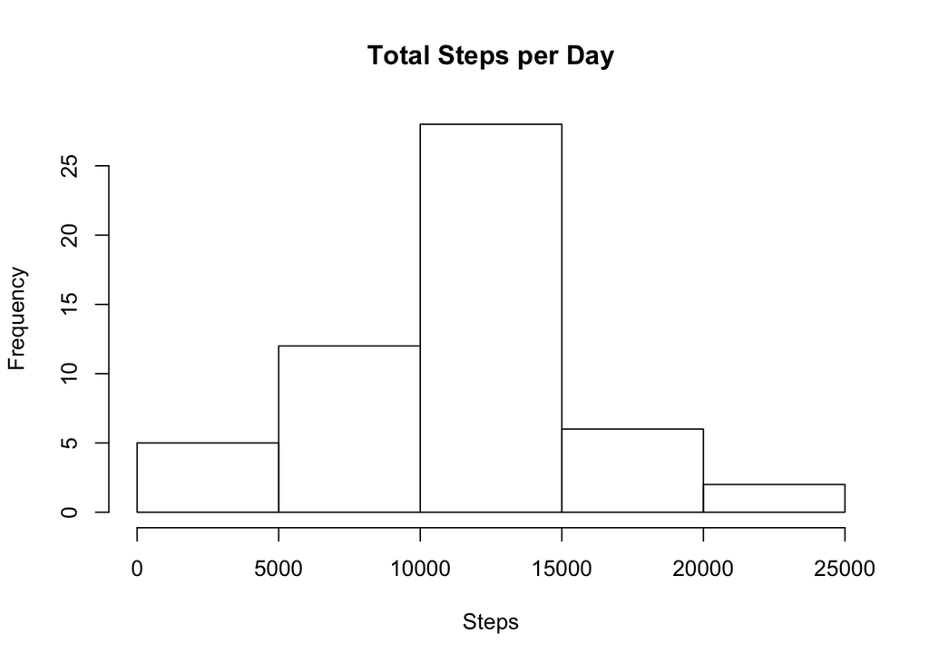

```r
hist(sumTable$Steps, breaks=5, xlab="Steps", main = "Total Steps per Day")
```

We can also use this table to calculate the mean steps per day

```r
as.integer(mean(sumTable$Steps))
```

```
## [1] 10766
```

And, to calculate the median steps per day

```r
as.integer(median(sumTable$Steps))
```

```
## [1] 10765
```

## Task #2

Now we want to look at the daily activity pattern for the entire dataset.

We begin by creating a table of averages for 5 minutes intervals throughout the day.

```r
intervalTable <- ddply(clean, .(interval), summarize, Avg = mean(steps))
```

Then we can plot this data in a line plot to get an idea of the daily pattern.

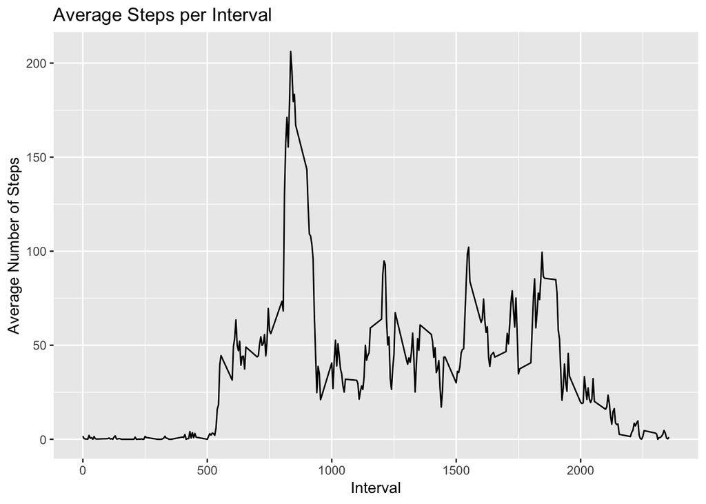

```r
p <- ggplot(intervalTable, aes(x=interval, y=Avg), xlab = "Interval", ylab="Average Number of Steps")
p + geom_line()+xlab("Interval")+ylab("Average Number of Steps")+ggtitle("Average Steps per Interval")
```

We can also determine which interval has the maximum number of steps on average.

```r
maxSteps <- max(intervalTable$Avg)
intervalTable[intervalTable$Avg==maxSteps,1]
```

```
## [1] 835
```

## Task #3

This task looks at imputing the missing values with a value of our choice. For this I chose to use the average steps for the day at the missing given interval

First we look at the number of null (NA) values in the original dataset:

```r
nrow(activity[is.na(activity$steps),])
```

```
## [1] 2304
```

Next we create a dataset that includes just the NA values from the original data.

```r
NAdata<- activity[is.na(activity$steps),]
```

Next we want to determine the average number of steps on a day during an interval

```r
avgTable <- ddply(clean, .(interval, day), summarize, Avg = mean(steps))
```

Then we merge the data from above and the NA table we created

```r
newdata<-merge(NAdata, avgTable, by=c("interval", "day"))
```

We need to Reorder the new data in the same format as clean data set

```r
newdata2<- newdata[,c(6,4,1,2,5)]
colnames(newdata2)<- c("steps", "date", "interval", "day", "DateTime")
```

Then, we merge the imputed data into the clean dataset that we were just using in tasks 1 & 2:

```r
AllData <- rbind(clean, newdata2)
```

Now we can analyze this new dataset and compare it to the answers in task 1

We start by creating the sum of steps per date to compare with step 1

```r
sumTable2 <- aggregate(AllData$steps ~ AllData$date, FUN=sum, )
colnames(sumTable2)<- c("Date", "Steps")
```

Next we can calculate the mean of the steps in the new data table:

```r
as.integer(mean(sumTable2$Steps))
```

```
## [1] 10821
```

Lastly we can create a histogram to look at the difference between the steps in the table without NA values and this new table with the NA values added in.

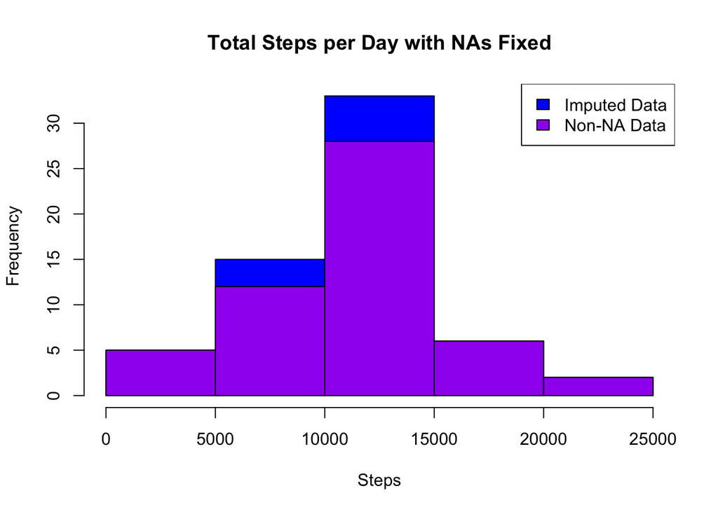

```r
hist(sumTable2$Steps, breaks=5, xlab="Steps", main = "Total Steps per Day with NAs Fixed", col="Blue")
hist(sumTable$Steps, breaks=5, xlab="Steps", main = "Total Steps per Day with NAs Fixed", col="Purple", add=T)
legend("topright", c("Imputed Data", "Non-NA Data"), fill=c("blue", "purple") )
```

## Task #4

Lastly, we want to compare the number of steps taken on the weekend days vs. week days

We need to create new category based on the days of the week

```r
AllData$DayCategory <- ifelse(AllData$day %in% c("Saturday", "Sunday"), "Weekend", "Weekday")
```

Next we want to look at the average steps taken on the weekend days versus the weekdays. To do this we need to separate the table into weekdays and weekends.

```r
intervalTable2 <- ddply(AllData, .(interval, DayCategory), summarize, Avg = mean(steps))
```

Then we want to plot the data in a panel plot with the intervals on the x axis and then number of steps on the y axis. The two panels are for weekends and weekday averages.

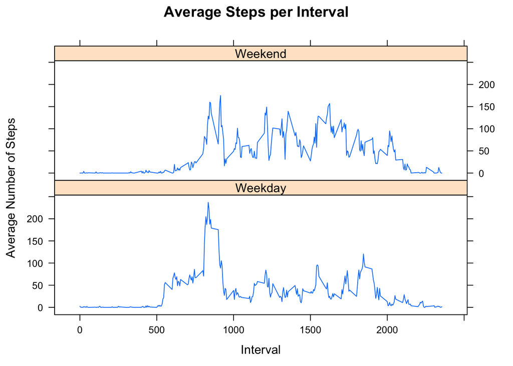

```r
xyplot(Avg~interval|DayCategory, data=intervalTable2, type="l",  layout = c(1,2),
       main="Average Steps per Interval",
       ylab="Average Number of Steps", xlab="Interval")
```